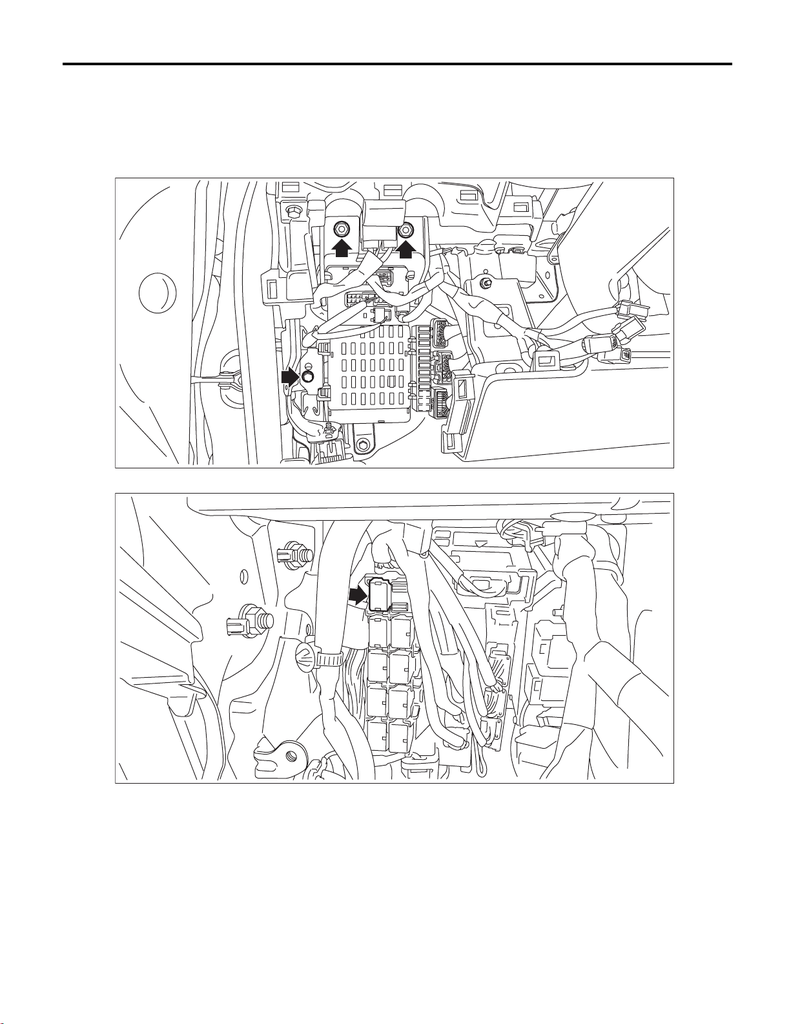

FU(w/o STI)-137

Oxygen Sensor Relay

FUEL INJECTION (FUEL SYSTEMS)

27.Oxygen Sensor Relay

A: REMOVAL

1) Disconnect the ground terminal from battery sensor. <Ref. to NT-5, BATTERY, NOTE, Note.>

2) Remove the instrument panel lower cover. <Ref. to EI-61, REMOVAL, Instrument Panel Lower Cover.>

3) Remove the nut and bolt, and move the fuse block downwards.

4) Remove the oxygen sensor relay from the relay block.

B: INSTALLATION

Install in the reverse order of removal.

Tightening torque:

7.5 N·m (0.8 kgf-m, 5.5 ft-lb)

FU-06875

FU-07837

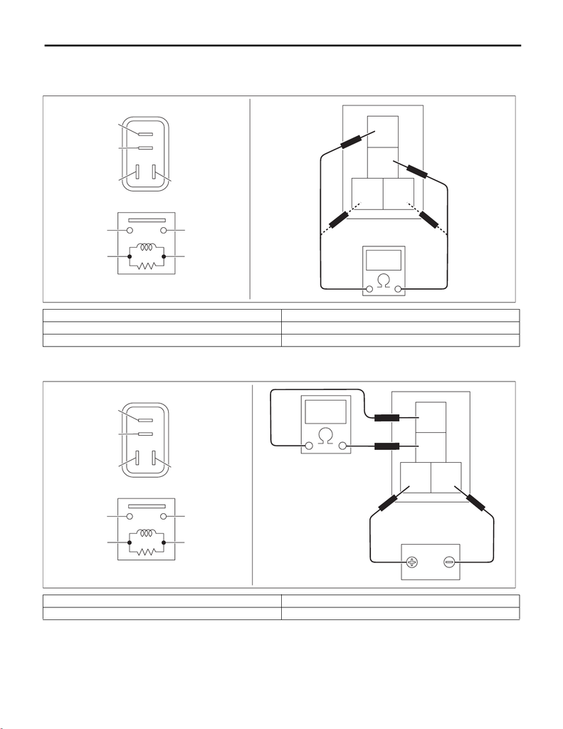

FU(w/o STI)-138

Oxygen Sensor Relay

FUEL INJECTION (FUEL SYSTEMS)

C: INSPECTION

1) Check that the oxygen sensor relay has no deformation, cracks or other damages.

2) Measure the resistance between oxygen sensor relay terminals.

Terminal No. Standard

1 and 2 1 MΩ or more

3 and 4 93.8 — 136.4 Ω (when 20°C (68°F))

Terminal No. Standard

1 and 2 Less than 1 Ω

FU-05961

(1)

(2)

(1)

(4)

(2)

(3)

(3)

(4)

1

2

3

4

FU-05963

(1)

(2)

(1)

(4)

(2)

(3)

(3)

(4)

1

2

3

4